# Bayesian time series toolkits in R: Prophet & BSTS

The code below accomapnies the [talk](https://www.meetup.com/Stan-User-Group-Berlin/events/262480224/) that was given for the [Berlin Bayesian](https://www.meetup.com/Stan-User-Group-Berlin/) meetup group on 08/07/2019 in Berlin. This is not a standalone tutorial, but can give you some idea of what to expect when working with both packages. You can find the slides [here](https://docs.google.com/presentation/d/19r3fZi58rkh2-NPUwJS5gWiS1Du8pNzo9d2p2Xrmkek/edit?usp=sharing) and I will upload a full recording video soon :)

# Setup

```r
library(tidyverse)
library(prophet)
library(bsts)
library(CausalImpact)
source('R/bsts_aux_functions.R')
```

# Data

```r
d <- read_csv('data/generated_data.csv')
```

The data includes several time series: daily counts of site visitors from 5 sources (`source1-5`) and daily counts of hits from a search engine.

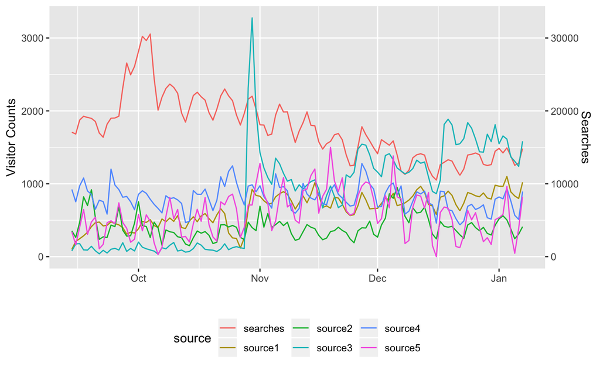

```r
d %>%
  mutate(searches = searches / 10) %>%
  # select(date, starts_with('source')) %>%
  gather('source', 'count', -date) %>%
  ggplot(aes(x = date, y = count, colour = source)) %>%
  +geom_line() %>%
  +xlab('') %>%
  +ylab('Visitor Counts') %>%
  +scale_y_continuous(sec.axis = sec_axis(name = 'Searches', trans = ~ 10 * .)) %>%
  +theme(legend.position = 'bottom')
```

We are interested in making predictions / inference on visitors from `source1`. A glompse at the data shows that

1. There was an anomaly between 24-29/10 (we had technical problems around a new feature)
2. After the problems were solved we stabilized on a bew baseline.

Ideally we would like to estimate the damage done during the “dip” we had, and get some understanding what was the new baseline.

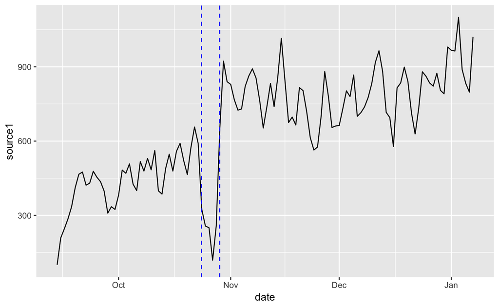

```r
dip_dates <- c(start = as.POSIXct('2015-10-24'), end = as.POSIXct('2015-10-29'))
d %>%
  ggplot() %>%
  +geom_line(aes(x = date, y = source1)) %>%
  +geom_vline(xintercept = dip_dates['start'], colour = 'blue', lty = 2) %>%
  +geom_vline(xintercept = dip_dates['end'], colour = 'blue', lty = 2)
```

# Prophet

## Data structure

`prophet` requires specific colimn names `y` & `ds` to run properly:

```r
prophet_data <- d %>% rename(y = source1, ds = date)
test_window <- 30 # days for testing
```

## Model run

Go ahead and try different model setups by un/commenting the different lines (shown below is the most “complex” model). The output is the standard `Stan` output.

```r
pr1 <- prophet(
  ## Manual changes dates
  changepoints = c(as.POSIXct('2015-10-24'), as.POSIXct('2015-10-29')),
  # changepoint.prior.scale = 0.5,
  # interval.width = 3,
  ## Seasonality
  weekly.seasonality = TRUE,
  yearly.seasonality = FALSE,
  fit = FALSE,
  mcmc.samples = 1000) %>%
  ## Adding regressors
  add_regressor(name = 'searches') %>%
  add_regressor(name = 'source2') %>%
  fit.prophet(
    prophet_data %>% filter(ds <= max(ds) - test_window * 24 * 3600)
  )
```

## Analysis

Out of the box, the `prophet` object allows plotting of model fit to historical & new results (this is a `ggplot2` plot and you can add your own annotations as needed)

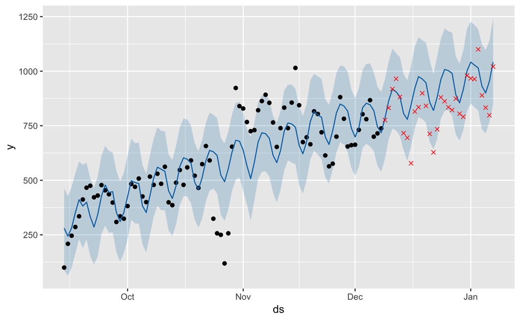

```r
prophet_data_pred <- predict(pr1, prophet_data) %>%
  mutate(test = if_else(ds > max(ds) - test_window * 24 * 3600, prophet_data$y, NA_real_))

pr1_plot <- plot(pr1, prophet_data_pred)
plot(pr1_plot + geom_point(aes(y = test), col ='red', pch = 4))
```

Adding change points:

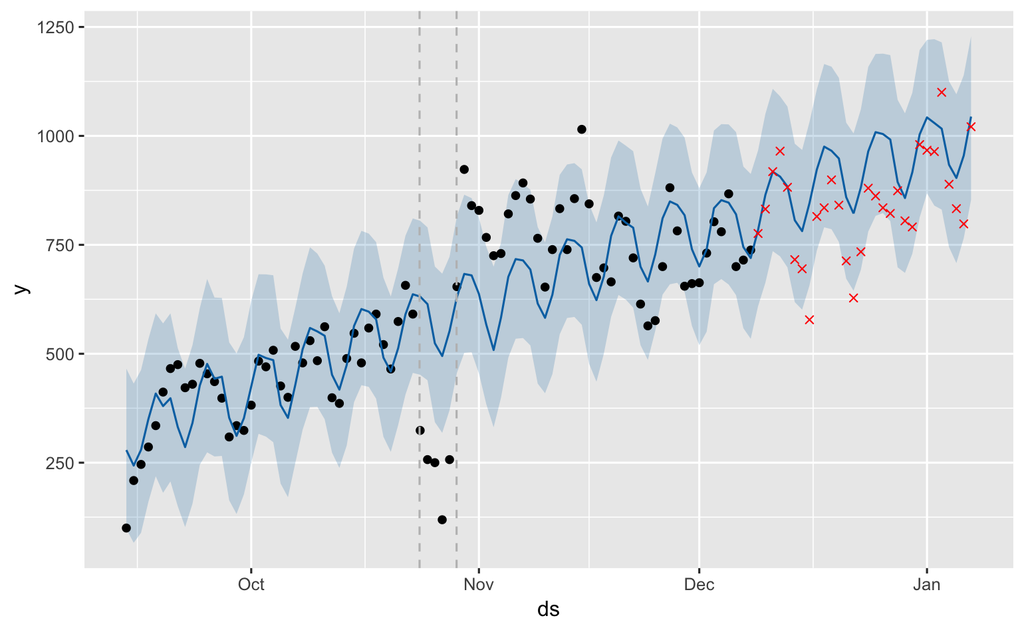

```r
pr1_plot_ch <- pr1_plot
for (ch_date in pr1$changepoints) {
  pr1_plot_ch <- pr1_plot_ch + geom_vline(xintercept = ch_date, colour = 'grey', lty = 2)
}

plot(pr1_plot_ch + geom_point(aes(y = test), col ='red', pch = 4))
```

### Model components

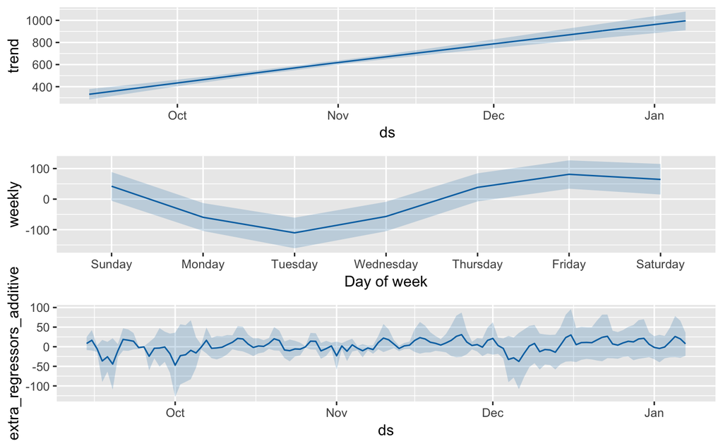

```r
prophet_plot_components(pr1, predict(pr1, prophet_data))
```

### Backtesting

`prohpet` also includes tools to evaluate model performance (backtesting). You can set the initial training period (`initial`), forecast horizon / window size (`horizon`) and spacing between cutoff dates (`period`) and it will run the models and sample:

```r
pr1_cv <- cross_validation(
  model = pr1,
  initial = 30,
  horizon = 30,
  units = 'days'
)
```

```
Making 2 forecasts with cutoffs between 2015-10-24 and 2015-11-08
```

```
Unknown or uninitialised column: 'y'.
```

```
Unknown or uninitialised column: 'y'.
```

The results of the CV exercise can be used to extract some pre-calculated error metrics:

```r
performance_metrics(pr1_cv) %>% head()
```

|  | horizon | mse | rmse | mae | mape | coverage |
| --- | --- | --- | --- | --- | --- | --- |
| 1 | 3 days | 56606.47 | 237.9211 | 185.5798 | 0.9554040 | 0.5000000 |
| 2 | 4 days | 50407.60 | 224.5164 | 166.9287 | 0.9121502 | 0.5000000 |
| 3 | 5 days | 42956.89 | 207.2604 | 150.6910 | 0.7849824 | 0.6666667 |
| 4 | 6 days | 34468.84 | 185.6579 | 138.9094 | 0.3051701 | 0.6666667 |
| 5 | 7 days | 33358.52 | 182.6431 | 152.6203 | 0.1752832 | 0.6666667 |
| 6 | 8 days | 40137.23 | 200.3428 | 179.5118 | 0.2022365 | 0.5000000 |

And come with some defauly plots:

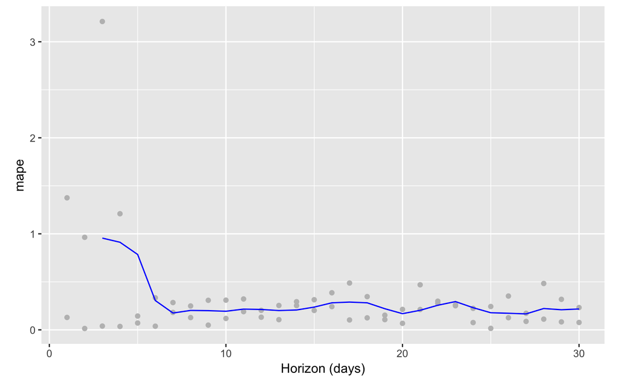

```r
plot_cross_validation_metric(pr1_cv, metric = 'mape')
```

# BSTS

## Data structure

BSTS requires a different data structure: a time series DF from the `zoo` package

```r
bsts_data <- zoo(d %>% dplyr::select(-date), order.by = d %>% pull(date))

bsts_data_train <- bsts_data
bsts_data_train$source1[index(bsts_data) > max(index(bsts_data)) - test_window * 24 * 3600] <- NA
bsts_data_test <-  bsts_data[index(bsts_data) >  max(index(bsts_data)) - test_window * 24 * 3600, ]
```

## Model run

Fittling the model starts with an empty `list` and chaining the different components of the model, and finally feeding this structure to the `bsts` function where the potential regressors are declared:

```r
b1 <- list() %>%
  # AddLocalLevel(y = bsts_data$source1) %>%
  AddAr(y = bsts_data_train$source1, lag = 1) %>%
  AddRegressionHoliday(
    y = bsts_data_train$source1,
    holiday.list = list(FixedDateHoliday(
      holiday.name = 'Dip',
      month = months(dip_dates['start']),
      day = lubridate::day(dip_dates['start']),
      days.before = 0,
      days.after = as.integer(dip_dates['end'] - dip_dates['start'])
    ))
  ) %>%
  # Weekly cycles
  AddSeasonal(y = bsts_data_train$source1, nseasons = 7) %>%
  bsts(
    formula = source1 ~ searches + source2 + source3 + source4 + source5 + 1,
    data = bsts_data_train,
    state.specification = .,
    niter = 1000
    # family = 'poisson'
  )
```

```
=-=-=-=-= Iteration 0 Wed Jul 10 14:48:30 2019 =-=-=-=-=
=-=-=-=-= Iteration 100 Wed Jul 10 14:48:30 2019 =-=-=-=-=
=-=-=-=-= Iteration 200 Wed Jul 10 14:48:30 2019 =-=-=-=-=
=-=-=-=-= Iteration 300 Wed Jul 10 14:48:31 2019 =-=-=-=-=
=-=-=-=-= Iteration 400 Wed Jul 10 14:48:31 2019 =-=-=-=-=
=-=-=-=-= Iteration 500 Wed Jul 10 14:48:31 2019 =-=-=-=-=
=-=-=-=-= Iteration 600 Wed Jul 10 14:48:31 2019 =-=-=-=-=
=-=-=-=-= Iteration 700 Wed Jul 10 14:48:32 2019 =-=-=-=-=
=-=-=-=-= Iteration 800 Wed Jul 10 14:48:32 2019 =-=-=-=-=
=-=-=-=-= Iteration 900 Wed Jul 10 14:48:32 2019 =-=-=-=-=
```

```r
b1_burn <- SuggestBurn(0.1, b1)
```

## Analysis

`bsts` uses `R`’s default plotting system (and again you can add your annotaion but in a different way). The default plot uses a gradient to show the posterior distribution:

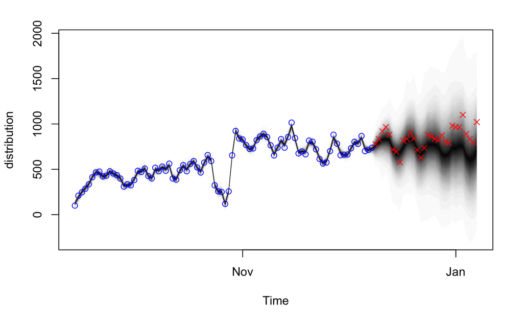

```r
PlotBstsState(b1, style = 'dynamic')
points(bsts_data_test$source1, col= 'red', pch = 4)
```

But boxplots might be a bit more informative:

```r
PlotBstsState(b1, style = 'boxplot', pch = '.')
points(bsts_data_train$source1, col= 'blue', pch = 1)
```

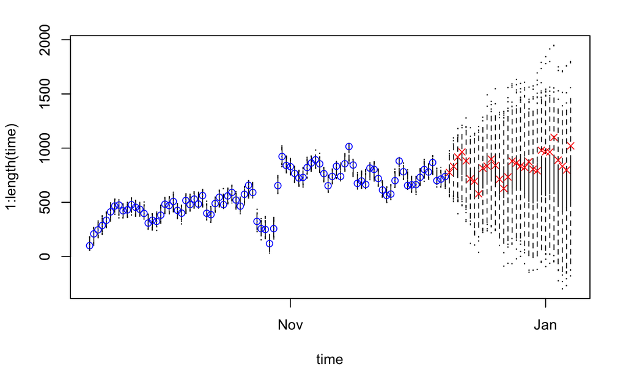

```r
points(bsts_data_test$source1, col= 'red', pch = 4)
```

### Backtesting

We can run a similar analysis of the day-to-day errors our model produces (which is a subset of what `prohpet` has, but still useful)

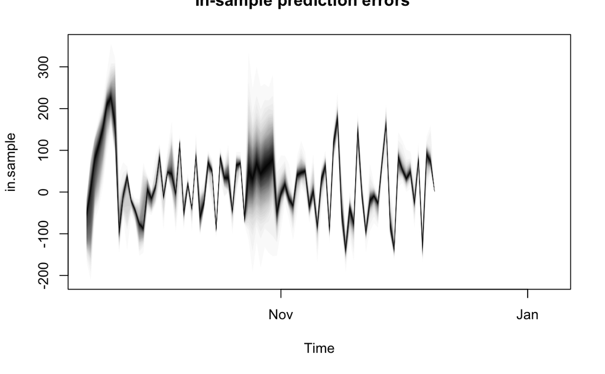

Looking into the model

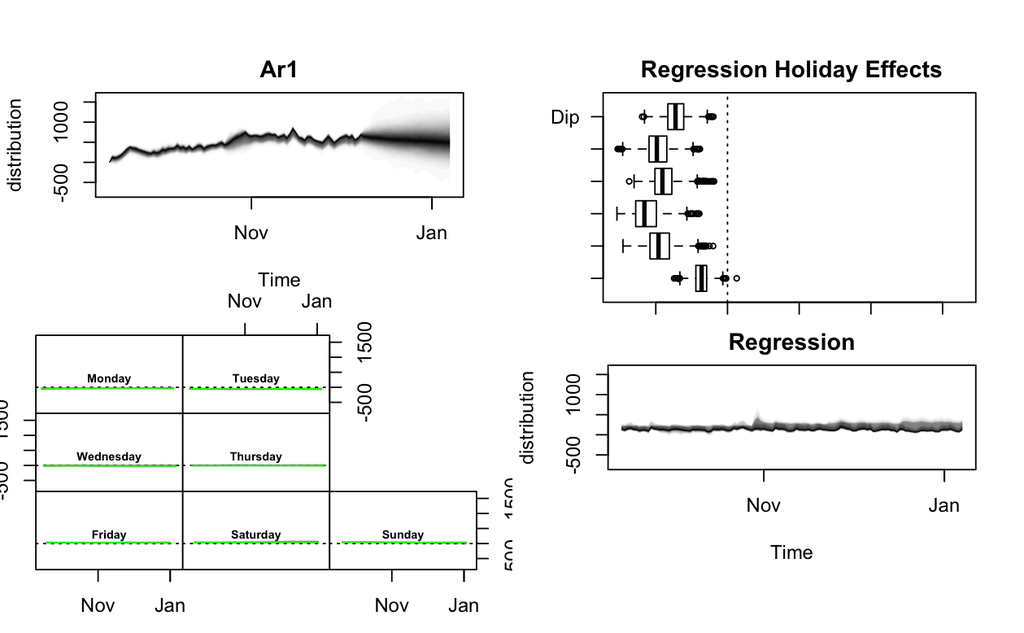

```r
# bsts_plot_components(b1)
plot(b1, 'components')
```

And a slightly different view (code in the repository for this)

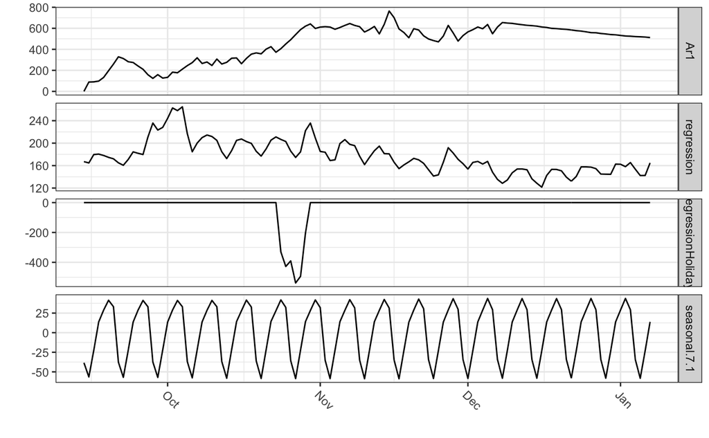

### Regression components

#### Spike

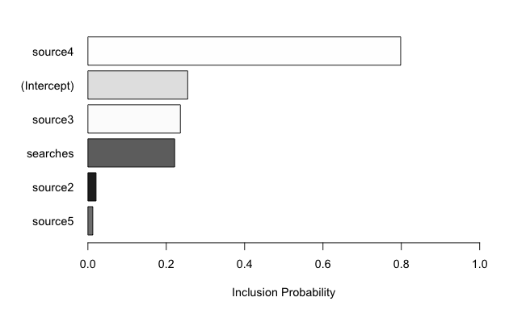

#### Slab

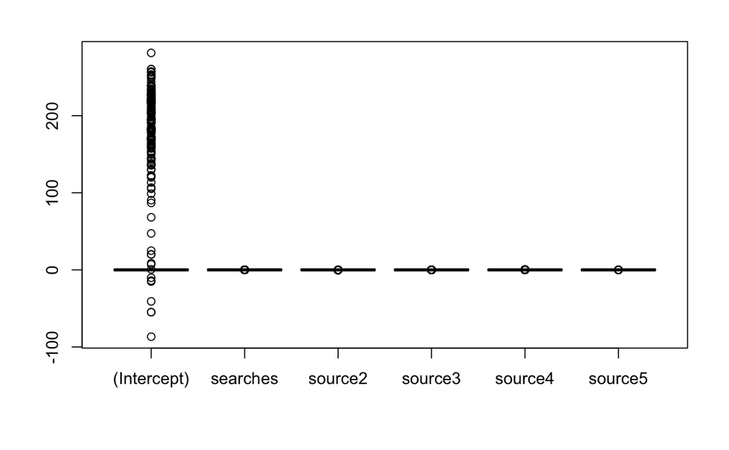

```r
boxplot(b1$coefficients[-(1:b1_burn),])
```

Zooming in on the other series:

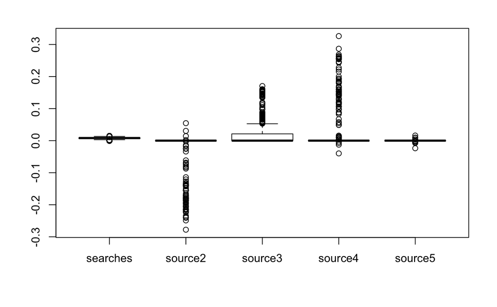

# CausalImpact

We know something has changes on 09/12: for example we launched a campaign that trageted visitors from `source1`. We want to know what was the impact of this change, but since we can’t have a control group, how do we measure the impact? The idea behind `CausalImpacct` is to use the results of a historically-validated model to build the “counter-factual”: we simulate “what would have happened” (our model predictions, assuming they are reliable) and compare to what actually happen. Since this is a bayesian model we can observe the posterior distribution of the difference directly:

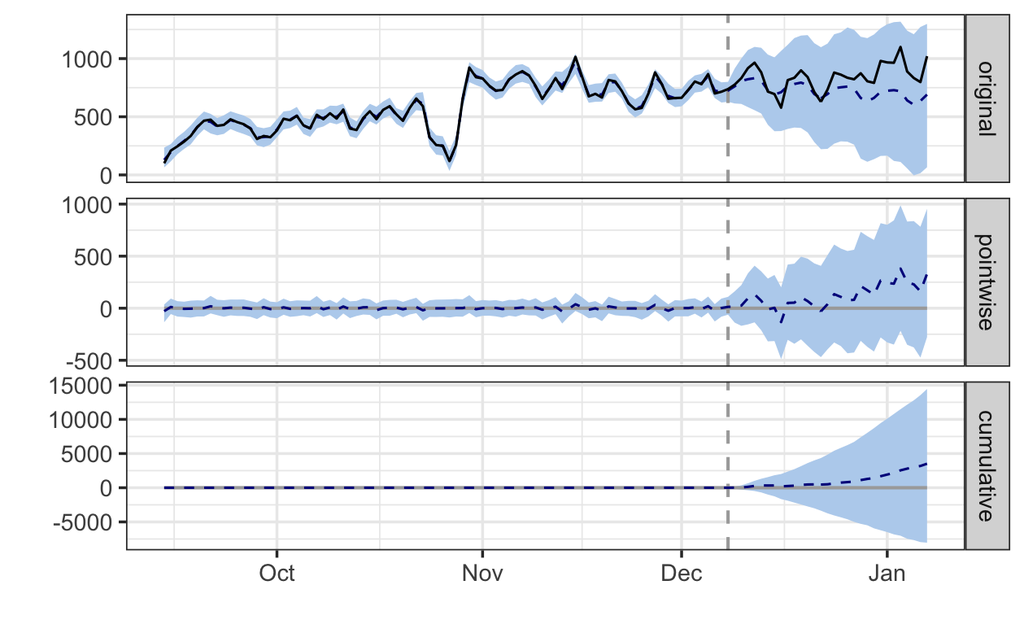

```r
cs3 <- CausalImpact(bsts.model = b1, post.period.response = as.integer(bsts_data_test$source1))
plot(cs3)
```

And report the results we want to report

```r
print(cs3, 'report')
```

[output not shown]